# Project - (Prosper Loan Data Exploration)

## Introduction

> Prosper Loan Data (prosperloanData.csv) represents personal loans requested through Prosper's peer to peer loan servicing network. This data set contains 113,937 loans with 81 variables on each loan, including loan amount, borrower rate (or interest rate), current loan status, borrower income, and many others.

## Preliminary Wrangling

```python
# import all packages and set plots to be embedded inline
import numpy as np
import pandas as pd
import matplotlib.pyplot as plt
import seaborn as sb

%matplotlib inline
```

### Load the Dataset

```python
# load in the dataset into a pandas dataframe
df = pd.read_csv('prosperLoanData.csv')
```

```python
# The dimension of the dataset.
df.shape
```

```
(113937, 81)
```

```python
# Overview ofthe data composition
df.info()
```

```
<class 'pandas.core.frame.DataFrame'>
RangeIndex: 113937 entries, 0 to 113936
Data columns (total 81 columns):
ListingKey                             113937 non-null object
ListingNumber                          113937 non-null int64
ListingCreationDate                    113937 non-null object
CreditGrade                            28953 non-null object
Term                                   113937 non-null int64
LoanStatus                             113937 non-null object
ClosedDate                             55089 non-null object
BorrowerAPR                            113912 non-null float64
BorrowerRate                           113937 non-null float64
LenderYield                            113937 non-null float64
EstimatedEffectiveYield                84853 non-null float64
EstimatedLoss                          84853 non-null float64
EstimatedReturn                        84853 non-null float64
ProsperRating (numeric)                84853 non-null float64
ProsperRating (Alpha)                  84853 non-null object
ProsperScore                           84853 non-null float64
ListingCategory (numeric)              113937 non-null int64
BorrowerState                          108422 non-null object
Occupation                             110349 non-null object
EmploymentStatus                       111682 non-null object
EmploymentStatusDuration               106312 non-null float64
IsBorrowerHomeowner                    113937 non-null bool
CurrentlyInGroup                       113937 non-null bool
GroupKey                               13341 non-null object
DateCreditPulled                       113937 non-null object
CreditScoreRangeLower                  113346 non-null float64
CreditScoreRangeUpper                  113346 non-null float64
FirstRecordedCreditLine                113240 non-null object
CurrentCreditLines                     106333 non-null float64
OpenCreditLines                        106333 non-null float64
TotalCreditLinespast7years             113240 non-null float64
OpenRevolvingAccounts                  113937 non-null int64
OpenRevolvingMonthlyPayment            113937 non-null float64
InquiriesLast6Months                   113240 non-null float64
TotalInquiries                         112778 non-null float64
CurrentDelinquencies                   113240 non-null float64
AmountDelinquent                       106315 non-null float64
```

[output cut: 31 more lines]

```
LP_CustomerPayments                    113937 non-null float64
LP_CustomerPrincipalPayments           113937 non-null float64
LP_InterestandFees                     113937 non-null float64
LP_ServiceFees                         113937 non-null float64
LP_CollectionFees                      113937 non-null float64
LP_GrossPrincipalLoss                  113937 non-null float64
LP_NetPrincipalLoss                    113937 non-null float64
LP_NonPrincipalRecoverypayments        113937 non-null float64
PercentFunded                          113937 non-null float64
Recommendations                        113937 non-null int64
InvestmentFromFriendsCount             113937 non-null int64
InvestmentFromFriendsAmount            113937 non-null float64
Investors                              113937 non-null int64
dtypes: bool(3), float64(50), int64(11), object(17)
memory usage: 68.1+ MB
```

```python
df.head()
```

|  | ListingKey | ListingNumber | ListingCreationDate | CreditGrade | Term | LoanStatus | ClosedDate | BorrowerAPR | BorrowerRate | LenderYield | ... | LP_ServiceFees | LP_CollectionFees | LP_GrossPrincipalLoss | LP_NetPrincipalLoss | LP_NonPrincipalRecoverypayments | PercentFunded | Recommendations | InvestmentFromFriendsCount | InvestmentFromFriendsAmount | Investors |
| --- | --- | --- | --- | --- | --- | --- | --- | --- | --- | --- | --- | --- | --- | --- | --- | --- | --- | --- | --- | --- | --- |
| 0 | 1021339766868145413AB3B | 193129 | 2007-08-26 19:09:29.263000000 | C | 36 | Completed | 2009-08-14 00:00:00 | 0.16516 | 0.1580 | 0.1380 | ... | -133.18 | 0.0 | 0.0 | 0.0 | 0.0 | 1.0 | 0 | 0 | 0.0 | 258 |
| 1 | 10273602499503308B223C1 | 1209647 | 2014-02-27 08:28:07.900000000 | NaN | 36 | Current | NaN | 0.12016 | 0.0920 | 0.0820 | ... | 0.00 | 0.0 | 0.0 | 0.0 | 0.0 | 1.0 | 0 | 0 | 0.0 | 1 |
| 2 | 0EE9337825851032864889A | 81716 | 2007-01-05 15:00:47.090000000 | HR | 36 | Completed | 2009-12-17 00:00:00 | 0.28269 | 0.2750 | 0.2400 | ... | -24.20 | 0.0 | 0.0 | 0.0 | 0.0 | 1.0 | 0 | 0 | 0.0 | 41 |
| 3 | 0EF5356002482715299901A | 658116 | 2012-10-22 11:02:35.010000000 | NaN | 36 | Current | NaN | 0.12528 | 0.0974 | 0.0874 | ... | -108.01 | 0.0 | 0.0 | 0.0 | 0.0 | 1.0 | 0 | 0 | 0.0 | 158 |
| 4 | 0F023589499656230C5E3E2 | 909464 | 2013-09-14 18:38:39.097000000 | NaN | 36 | Current | NaN | 0.24614 | 0.2085 | 0.1985 | ... | -60.27 | 0.0 | 0.0 | 0.0 | 0.0 | 1.0 | 0 | 0 | 0.0 | 20 |

5 rows × 81 columns

```python
df.describe()
```

|  | ListingNumber | Term | BorrowerAPR | BorrowerRate | LenderYield | EstimatedEffectiveYield | EstimatedLoss | EstimatedReturn | ProsperRating (numeric) | ProsperScore | ... | LP_ServiceFees | LP_CollectionFees | LP_GrossPrincipalLoss | LP_NetPrincipalLoss | LP_NonPrincipalRecoverypayments | PercentFunded | Recommendations | InvestmentFromFriendsCount | InvestmentFromFriendsAmount | Investors |
| --- | --- | --- | --- | --- | --- | --- | --- | --- | --- | --- | --- | --- | --- | --- | --- | --- | --- | --- | --- | --- | --- |
| count | 1.139370e+05 | 113937.000000 | 113912.000000 | 113937.000000 | 113937.000000 | 84853.000000 | 84853.000000 | 84853.000000 | 84853.000000 | 84853.000000 | ... | 113937.000000 | 113937.000000 | 113937.000000 | 113937.000000 | 113937.000000 | 113937.000000 | 113937.000000 | 113937.000000 | 113937.000000 | 113937.000000 |
| mean | 6.278857e+05 | 40.830248 | 0.218828 | 0.192764 | 0.182701 | 0.168661 | 0.080306 | 0.096068 | 4.072243 | 5.950067 | ... | -54.725641 | -14.242698 | 700.446342 | 681.420499 | 25.142686 | 0.998584 | 0.048027 | 0.023460 | 16.550751 | 80.475228 |
| std | 3.280762e+05 | 10.436212 | 0.080364 | 0.074818 | 0.074516 | 0.068467 | 0.046764 | 0.030403 | 1.673227 | 2.376501 | ... | 60.675425 | 109.232758 | 2388.513831 | 2357.167068 | 275.657937 | 0.017919 | 0.332353 | 0.232412 | 294.545422 | 103.239020 |
| min | 4.000000e+00 | 12.000000 | 0.006530 | 0.000000 | -0.010000 | -0.182700 | 0.004900 | -0.182700 | 1.000000 | 1.000000 | ... | -664.870000 | -9274.750000 | -94.200000 | -954.550000 | 0.000000 | 0.700000 | 0.000000 | 0.000000 | 0.000000 | 1.000000 |
| 25% | 4.009190e+05 | 36.000000 | 0.156290 | 0.134000 | 0.124200 | 0.115670 | 0.042400 | 0.074080 | 3.000000 | 4.000000 | ... | -73.180000 | 0.000000 | 0.000000 | 0.000000 | 0.000000 | 1.000000 | 0.000000 | 0.000000 | 0.000000 | 2.000000 |
| 50% | 6.005540e+05 | 36.000000 | 0.209760 | 0.184000 | 0.173000 | 0.161500 | 0.072400 | 0.091700 | 4.000000 | 6.000000 | ... | -34.440000 | 0.000000 | 0.000000 | 0.000000 | 0.000000 | 1.000000 | 0.000000 | 0.000000 | 0.000000 | 44.000000 |
| 75% | 8.926340e+05 | 36.000000 | 0.283810 | 0.250000 | 0.240000 | 0.224300 | 0.112000 | 0.116600 | 5.000000 | 8.000000 | ... | -13.920000 | 0.000000 | 0.000000 | 0.000000 | 0.000000 | 1.000000 | 0.000000 | 0.000000 | 0.000000 | 115.000000 |
| max | 1.255725e+06 | 60.000000 | 0.512290 | 0.497500 | 0.492500 | 0.319900 | 0.366000 | 0.283700 | 7.000000 | 11.000000 | ... | 32.060000 | 0.000000 | 25000.000000 | 25000.000000 | 21117.900000 | 1.012500 | 39.000000 | 33.000000 | 25000.000000 | 1189.000000 |

8 rows × 61 columns

There are too many columns, I'll be creating a subset with all the columns needed for this project.

```python
#creating a subset

cols = ['LoanStatus', 'BorrowerAPR', 'BorrowerRate','EmploymentStatus','EstimatedReturn','ListingCategory (numeric)','LoanOriginationDate', 'Occupation','StatedMonthlyIncome',
        'IncomeVerifiable','IncomeRange','MonthlyLoanPayment', 'IsBorrowerHomeowner','DebtToIncomeRatio', 'LoanOriginalAmount', 'Term', 'ProsperRating (Alpha)']
loans = df[cols]
```

```python
loans.head(10)
```

|  | LoanStatus | BorrowerAPR | BorrowerRate | EmploymentStatus | EstimatedReturn | ListingCategory (numeric) | LoanOriginationDate | Occupation | StatedMonthlyIncome | IncomeVerifiable | IncomeRange | MonthlyLoanPayment | IsBorrowerHomeowner | DebtToIncomeRatio | LoanOriginalAmount | Term | ProsperRating (Alpha) |
| --- | --- | --- | --- | --- | --- | --- | --- | --- | --- | --- | --- | --- | --- | --- | --- | --- | --- |
| 0 | Completed | 0.16516 | 0.1580 | Self-employed | NaN | 0 | 2007-09-12 00:00:00 | Other | 3083.333333 | True | $25,000-49,999 | 330.43 | True | 0.17 | 9425 | 36 | NaN |
| 1 | Current | 0.12016 | 0.0920 | Employed | 0.05470 | 2 | 2014-03-03 00:00:00 | Professional | 6125.000000 | True | $50,000-74,999 | 318.93 | False | 0.18 | 10000 | 36 | A |
| 2 | Completed | 0.28269 | 0.2750 | Not available | NaN | 0 | 2007-01-17 00:00:00 | Other | 2083.333333 | True | Not displayed | 123.32 | False | 0.06 | 3001 | 36 | NaN |
| 3 | Current | 0.12528 | 0.0974 | Employed | 0.06000 | 16 | 2012-11-01 00:00:00 | Skilled Labor | 2875.000000 | True | $25,000-49,999 | 321.45 | True | 0.15 | 10000 | 36 | A |
| 4 | Current | 0.24614 | 0.2085 | Employed | 0.09066 | 2 | 2013-09-20 00:00:00 | Executive | 9583.333333 | True | $100,000+ | 563.97 | True | 0.26 | 15000 | 36 | D |
| 5 | Current | 0.15425 | 0.1314 | Employed | 0.07077 | 1 | 2013-12-24 00:00:00 | Professional | 8333.333333 | True | $100,000+ | 342.37 | True | 0.36 | 15000 | 60 | B |
| 6 | Current | 0.31032 | 0.2712 | Employed | 0.11070 | 1 | 2013-04-18 00:00:00 | Sales - Retail | 2083.333333 | True | $25,000-49,999 | 122.67 | False | 0.27 | 3000 | 36 | E |
| 7 | Current | 0.23939 | 0.2019 | Employed | 0.09840 | 2 | 2013-05-13 00:00:00 | Laborer | 3355.750000 | True | $25,000-49,999 | 372.60 | False | 0.24 | 10000 | 36 | C |
| 8 | Current | 0.07620 | 0.0629 | Employed | 0.04231 | 7 | 2013-12-12 00:00:00 | Food Service | 3333.333333 | True | $25,000-49,999 | 305.54 | True | 0.25 | 10000 | 36 | AA |
| 9 | Current | 0.07620 | 0.0629 | Employed | 0.04231 | 7 | 2013-12-12 00:00:00 | Food Service | 3333.333333 | True | $25,000-49,999 | 305.54 | True | 0.25 | 10000 | 36 | AA |

```python
loans.shape
```

```
(113937, 17)
```

```python
loans.describe()
```

|  | BorrowerAPR | BorrowerRate | EstimatedReturn | ListingCategory (numeric) | StatedMonthlyIncome | MonthlyLoanPayment | DebtToIncomeRatio | LoanOriginalAmount | Term |
| --- | --- | --- | --- | --- | --- | --- | --- | --- | --- |
| count | 113912.000000 | 113937.000000 | 84853.000000 | 113937.000000 | 1.139370e+05 | 113937.000000 | 105383.000000 | 113937.00000 | 113937.000000 |
| mean | 0.218828 | 0.192764 | 0.096068 | 2.774209 | 5.608026e+03 | 272.475783 | 0.275947 | 8337.01385 | 40.830248 |
| std | 0.080364 | 0.074818 | 0.030403 | 3.996797 | 7.478497e+03 | 192.697812 | 0.551759 | 6245.80058 | 10.436212 |
| min | 0.006530 | 0.000000 | -0.182700 | 0.000000 | 0.000000e+00 | 0.000000 | 0.000000 | 1000.00000 | 12.000000 |
| 25% | 0.156290 | 0.134000 | 0.074080 | 1.000000 | 3.200333e+03 | 131.620000 | 0.140000 | 4000.00000 | 36.000000 |
| 50% | 0.209760 | 0.184000 | 0.091700 | 1.000000 | 4.666667e+03 | 217.740000 | 0.220000 | 6500.00000 | 36.000000 |
| 75% | 0.283810 | 0.250000 | 0.116600 | 3.000000 | 6.825000e+03 | 371.580000 | 0.320000 | 12000.00000 | 36.000000 |
| max | 0.512290 | 0.497500 | 0.283700 | 20.000000 | 1.750003e+06 | 2251.510000 | 10.010000 | 35000.00000 | 60.000000 |

```python
loans['ProsperRating (Alpha)'].unique()
```

```
array([nan, 'A', 'D', 'B', 'E', 'C', 'AA', 'HR'], dtype=object)
```

```python
#Check sum of null rows for each variable
loans.isnull().sum()
```

```
LoanStatus                       0
BorrowerAPR                     25
BorrowerRate                     0
EmploymentStatus              2255
EstimatedReturn              29084
ListingCategory (numeric)        0
LoanOriginationDate              0
Occupation                    3588
StatedMonthlyIncome              0
IncomeVerifiable                 0
IncomeRange                      0
MonthlyLoanPayment               0
IsBorrowerHomeowner              0
DebtToIncomeRatio             8554
LoanOriginalAmount               0
Term                             0
ProsperRating (Alpha)        29084
dtype: int64
```

```python
# Drop all rows with null values
loans.dropna(inplace=True)
```

```python
# Checking if there are still any rows with null values in the dataframe
loans.isnull().sum().sum()
```

```
0
```

```python
loans.info()
```

```
<class 'pandas.core.frame.DataFrame'>
Int64Index: 76224 entries, 1 to 113936
Data columns (total 17 columns):
LoanStatus                   76224 non-null object
BorrowerAPR                  76224 non-null float64
BorrowerRate                 76224 non-null float64
EmploymentStatus             76224 non-null object
EstimatedReturn              76224 non-null float64
ListingCategory (numeric)    76224 non-null int64
LoanOriginationDate          76224 non-null object
Occupation                   76224 non-null object
StatedMonthlyIncome          76224 non-null float64
IncomeVerifiable             76224 non-null bool
IncomeRange                  76224 non-null object
MonthlyLoanPayment           76224 non-null float64
IsBorrowerHomeowner          76224 non-null bool
DebtToIncomeRatio            76224 non-null float64
LoanOriginalAmount           76224 non-null int64
Term                         76224 non-null int64
ProsperRating (Alpha)        76224 non-null object
dtypes: bool(2), float64(6), int64(3), object(6)
memory usage: 9.5+ MB
```

```python
# Convert LoanOriginationDate from object to datetime datatypes
loans['LoanOriginationDate'] = pd.to_datetime(loans['LoanOriginationDate'])
```

```python
# Convert Stated Monthly Income from float to int datatypes

loans['StatedMonthlyIncome'] = loans['StatedMonthlyIncome'].astype(int)
```

```python
loans.info()
```

```
<class 'pandas.core.frame.DataFrame'>
Int64Index: 76224 entries, 1 to 113936
Data columns (total 17 columns):
LoanStatus                   76224 non-null object
BorrowerAPR                  76224 non-null float64
BorrowerRate                 76224 non-null float64
EmploymentStatus             76224 non-null object
EstimatedReturn              76224 non-null float64
ListingCategory (numeric)    76224 non-null int64
LoanOriginationDate          76224 non-null datetime64[ns]
Occupation                   76224 non-null object
StatedMonthlyIncome          76224 non-null int64
IncomeVerifiable             76224 non-null bool
IncomeRange                  76224 non-null object
MonthlyLoanPayment           76224 non-null float64
IsBorrowerHomeowner          76224 non-null bool
DebtToIncomeRatio            76224 non-null float64
LoanOriginalAmount           76224 non-null int64
Term                         76224 non-null int64
ProsperRating (Alpha)        76224 non-null object
dtypes: bool(2), datetime64[ns](1), float64(5), int64(4), object(5)
memory usage: 9.5+ MB
```

```python
loans.head()
```

|  | LoanStatus | BorrowerAPR | BorrowerRate | EmploymentStatus | EstimatedReturn | ListingCategory (numeric) | LoanOriginationDate | Occupation | StatedMonthlyIncome | IncomeVerifiable | IncomeRange | MonthlyLoanPayment | IsBorrowerHomeowner | DebtToIncomeRatio | LoanOriginalAmount | Term | ProsperRating (Alpha) |
| --- | --- | --- | --- | --- | --- | --- | --- | --- | --- | --- | --- | --- | --- | --- | --- | --- | --- |
| 1 | Current | 0.12016 | 0.0920 | Employed | 0.05470 | 2 | 2014-03-03 | Professional | 6125 | True | $50,000-74,999 | 318.93 | False | 0.18 | 10000 | 36 | A |
| 3 | Current | 0.12528 | 0.0974 | Employed | 0.06000 | 16 | 2012-11-01 | Skilled Labor | 2875 | True | $25,000-49,999 | 321.45 | True | 0.15 | 10000 | 36 | A |
| 4 | Current | 0.24614 | 0.2085 | Employed | 0.09066 | 2 | 2013-09-20 | Executive | 9583 | True | $100,000+ | 563.97 | True | 0.26 | 15000 | 36 | D |
| 5 | Current | 0.15425 | 0.1314 | Employed | 0.07077 | 1 | 2013-12-24 | Professional | 8333 | True | $100,000+ | 342.37 | True | 0.36 | 15000 | 60 | B |
| 6 | Current | 0.31032 | 0.2712 | Employed | 0.11070 | 1 | 2013-04-18 | Sales - Retail | 2083 | True | $25,000-49,999 | 122.67 | False | 0.27 | 3000 | 36 | E |

I did a little data wrangling to ensure my data is ready for visualization.

### What is the structure of your dataset?

> There are 113,937 rows with 81 variables on each loan, including loan amount, borrower rate, StatedMonthlyIncome, current loan status, occupation, and many others. Most of the variables are numeric in nature.

### What is/are the main feature(s) of interest in your dataset?

> The dataset has plenty of features to explore. For the purpose of this analysis, I'll explore how the numerical and categorical features influences the amount borrowed and many more.

## Univariate Exploration

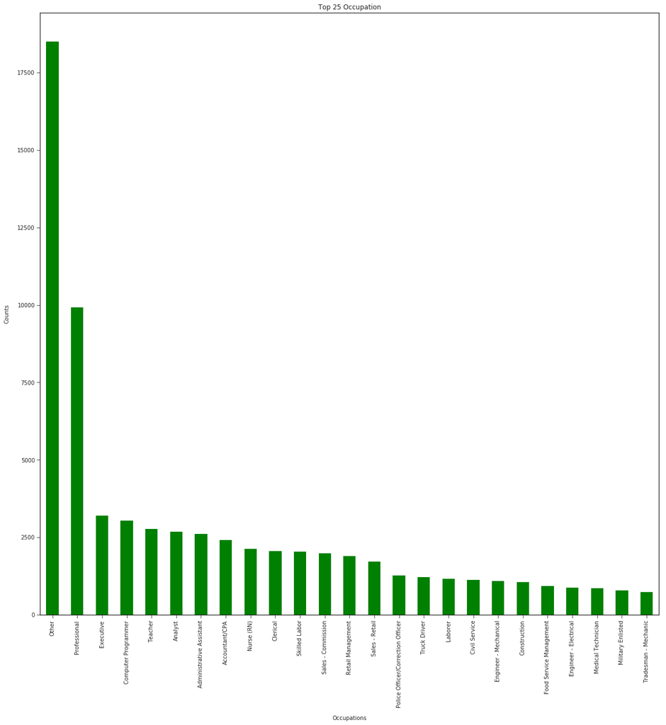

```python
#plotting a bar plot showing the Top 25 Occupations By Count
loans['Occupation'].value_counts()[:25].plot.bar(title= 'Top 25 Occupation',figsize= (20,20),color= 'green')
plt.xlabel("Occupations", labelpad=14)
plt.ylabel("Counts", labelpad=14)
plt.show()
```

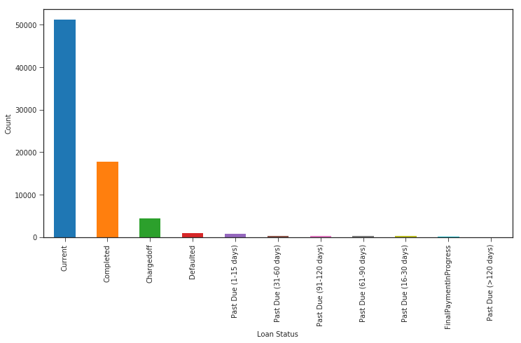

```python
# plot a bar chart for the loan statuses
plt.figure(figsize = [12, 6])
loans['LoanStatus'].value_counts().plot.bar()
plt.xlabel('Loan Status')
plt.ylabel('Count')
plt.show()
```

From this plot, We can see that majority of the loans in the dataset fall in the categories of Current,Completed, Chargedoff, Defaulted and Past Due(1-15 days)

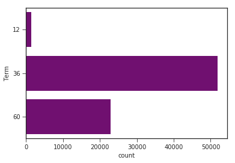

```python
#plotting to show the loan Terms.

sb.countplot(data = loans, y = 'Term', color= 'purple');
```

This plot shows that there are three loan terms, the most popular term is 36 months(3years) while other borrowers go for the 60 months term (5 years)

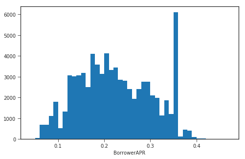

```python
# Plotting a hist for BorrowerAPR with bins
bins = np.arange(0.04, loans['BorrowerAPR'].max()+0.05, 0.01)
plt.figure(figsize=[8, 5])
plt.hist(data = loans, x = 'BorrowerAPR', bins=bins);
plt.xlabel('BorrowerAPR');
```

The plot appears to be multimodal. There is a small peak close to 0.1, on both sides of 0.2 there are two more peaks and another peak centered at 0.3 mark. There is a very high peak at 0.36. Only very few loans have APR greater than 0.4.

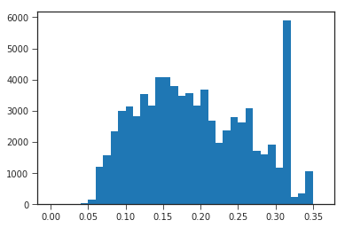

```python
# BorrowerRate Histogram
bins = np.arange(0, loans['BorrowerRate'].max()+0.01, 0.01)
plt.hist(data = loans, x = 'BorrowerRate', bins = bins);
```

Borrower Rates mostly look normally distributed around 0.15 with a a slight right skew and a high peak at 0.32.

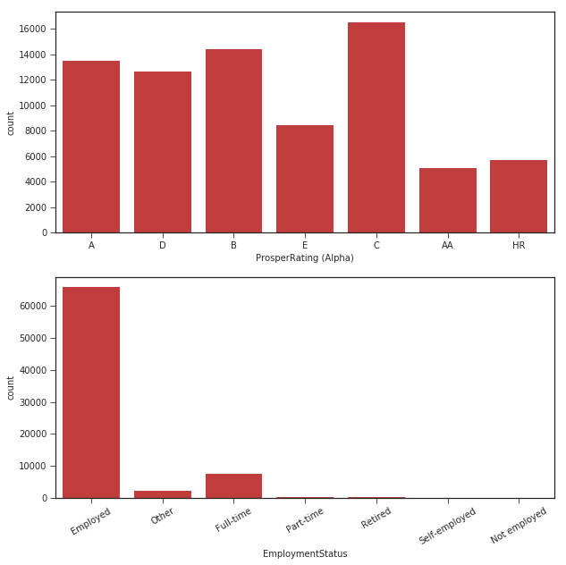

```python
#Plotting to show Employment status and ProsperRating
fig, ax = plt.subplots(nrows=2, figsize = [10,10])
default_color = sb.color_palette()[3]
sb.countplot(data = loans, x = 'ProsperRating (Alpha)', color = default_color, ax = ax[0])
sb.countplot(data = loans, x = 'EmploymentStatus', color = default_color, ax = ax[1]);
plt.xticks(rotation=30);
```

These plots shows that most of the ratings of the borrowers are among A to c. Most of borrowers are either employed or full-time.

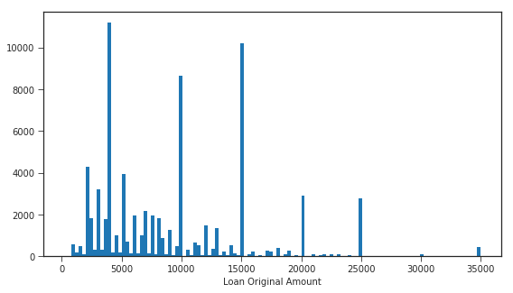

```python
plt.figure(figsize=[20,5])

plt.subplot(1,2,1)
bins = np.arange(200, loans.LoanOriginalAmount.max()+300, 300)
plt.hist(data = loans, x = 'LoanOriginalAmount', bins = bins);
plt.xlabel('Loan Original Amount');
```

The top three most common original loan amount is 4000, followed by 15000, then 10000.

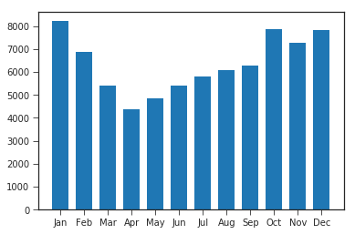

```python
# LoanOriginalDate Histogram - Months
bin_edges = np.arange(loans['LoanOriginationDate'].dt.month.min()-0.5, loans['LoanOriginationDate'].dt.month.max()+1.5, 1)
ticks = [ 1, 2, 3, 4, 5, 6, 7, 8, 9, 10, 11, 12]
labels = ['Jan', 'Feb', 'Mar', 'Apr', 'May', 'Jun', 'Jul', 'Aug', 'Sep', 'Oct', 'Nov', 'Dec']
plt.hist(loans['LoanOriginationDate'].dt.month, bins=bin_edges, rwidth=0.7);
plt.xticks(ticks, labels);
```

The chart shows that the months with the most frequent Loan Origination Dates are January, October, December.

#### Listing

```python
loans['ListingCategory (numeric)'].value_counts()
```

```
1     48609
7      8281
2      6328
3      3645
6      2032
13     1767
15     1382
14      795
18      783
20      730
19      712
16      289
11      201
5       201
8       191
9        83
10       82
17       49
12       45
0        19
Name: ListingCategory (numeric), dtype: int64
```

```python
listing_categories = {0 : 'Not Available',
                1 : 'Debt Consolidation',
                2 : 'Home Improvement',
                3 : 'Business',
                4 : 'Personal Loan',
                5 : 'Student Use',
                6 : 'Auto',
                7 : 'Other',
                8 : 'Baby&Adoption',
                9 : 'Boat',
                10 : 'Cosmetic Procedure',
                11 : 'Engagement Ring',
                12 : 'Green Loans',
                13 : 'Household Expenses',
                14 : 'Large Purchases',
                15 : 'Medical/Dental',
                16 : 'Motorcycle',
                17 : 'RV',
                18 : 'Taxes',
                19 : 'Vacation',
                20 : 'Wedding Loans'}
```

```python
# replacing the existing numeric variables with the meanings

loans['ListingCategory'] = loans['ListingCategory (numeric)'].replace(to_replace=listing_categories)
```

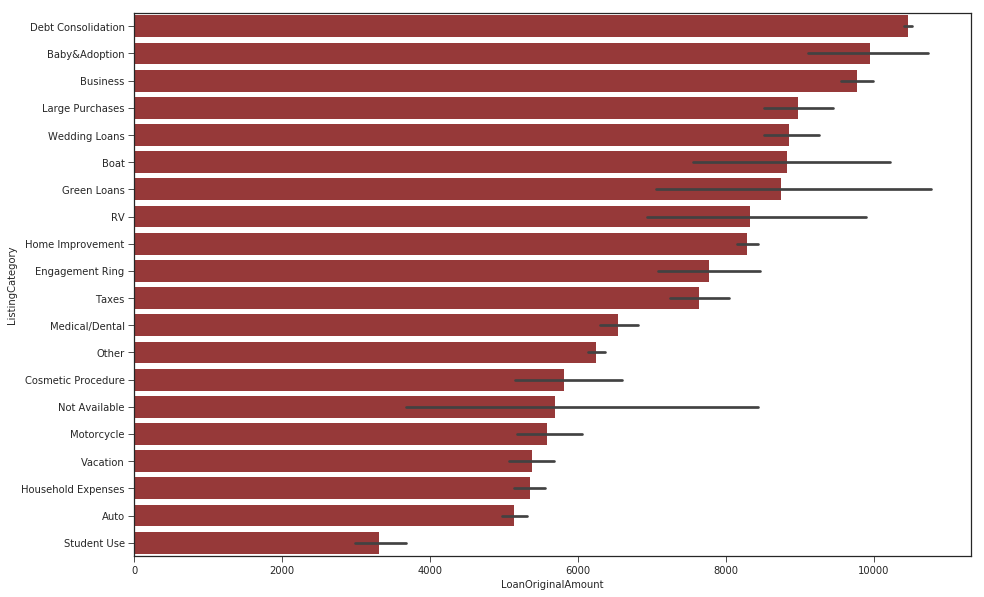

```python
# ListingCategory vs LoanOriginalAmount - Barplot
fig=plt.figure(figsize=[15,10])
listing_order = loans.groupby('ListingCategory')['LoanOriginalAmount'].mean().sort_values(ascending=False).index
sb.barplot(data=loans, y='ListingCategory', x='LoanOriginalAmount', color= 'brown', order=listing_order);
```

Debt Consolidation dominated the number of loans taken out. The other categories has a close range to Debt Consolidation.

### Discuss the distribution(s) of your variable(s) of interest. Were there any unusual points? Did you need to perform any transformations?

> The distribution of borrower's APR appears to be multimodal. There is a small peak close to 0.1, on both sides of 0.2 there are two more peaks and another peak centered at 0.3 mark. There is a very high peak at 0.36. Only very few loans have APR greater than 0.4.

### Of the features you investigated, were there any unusual distributions? Did you perform any operations on the data to tidy, adjust, or change the form of the data? If so, why did you do this?

> The plot that reflect the Loanorigination Date, I converted the datatype from object to datetime, to enable easy plotting.

> For the ListingCategories. I replaced the numbers with their corresponding meanings in other for us to get a more accurate picture of the variable.

## Bivariate Exploration

> In this section, I want to look at the pairwise correlations present between features in the data. I'll also separate the variables of interest into Numeric and Categorical for better visualization.

```python
# separate into numeric and categorical features

numeric = ['BorrowerAPR', 'BorrowerRate','DebtToIncomeRatio', 'StatedMonthlyIncome', 'MonthlyLoanPayment', 'LoanOriginalAmount']

category = ['Term', 'LoanStatus', 'EmploymentStatus', 'IsBorrowerHomeowner','IncomeRange', 'ProsperRating (Alpha)',
            'ListingCategory' ]
```

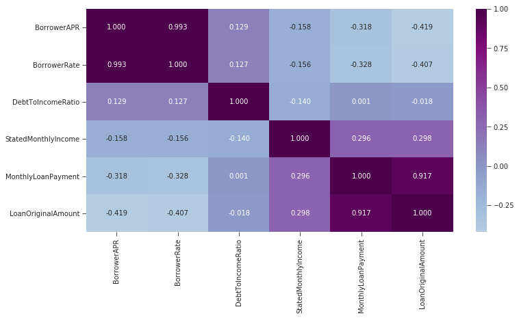

```python
# pairwaise correlation plot
plt.figure(figsize = [12, 6])
sb.heatmap(loans[numeric].corr(), annot = True, fmt = '.3f', center = 0, cmap = 'BuPu')
plt.show()
```

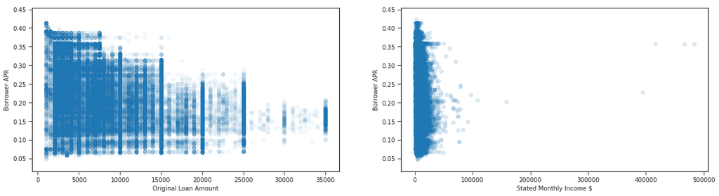

```python
# Scatter plot of Borrower APR against Original Loan Amount
plt.figure(figsize=[20, 5])

plt.subplot(1,2,1)
plt.scatter(data=loans, y='BorrowerAPR', x='LoanOriginalAmount', alpha= 1/20);
plt.ylabel('Borrower APR');
plt.xlabel('Original Loan Amount');

# Scatter plot of Borrower APR against Stated Monthly Income
plt.subplot(1,2,2)
plt.scatter(data=loans, y='BorrowerAPR', x='StatedMonthlyIncome', alpha= 3/20);
plt.ylabel('Borrower APR');
plt.xlabel('Stated Monthly Income $');
```

With the Original Loan amount plot, I observed that loan amounts between 30000 and 35000 have an APR between the range of 0.10 and 0.20. And as the loan amount increases the borrower APR range becomes smaller.

From the right plot we see that monthly incomes do not seem to really have a strong and clear effect on the APRs. We can use heatmap to explore this further.

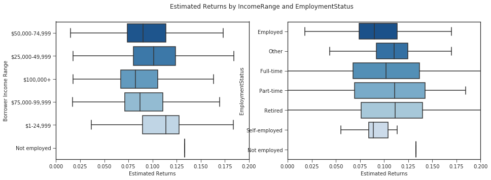

```python
# boxplots
plt.figure(figsize = [15, 5])

plt.subplot(1, 2, 1)
base_color = sb.color_palette()[0]
sb.boxplot(data = loans, y = 'IncomeRange', x = 'EstimatedReturn', palette = "Blues_r", showfliers = False)
plt.xlim(0,.2)
plt.ylabel('Borrower Income Range')
plt.xlabel('Estimated Returns')

plt.subplot(1, 2, 2)
base_color = sb.color_palette()[0]
sb.boxplot(data = loans, y = 'EmploymentStatus', x = 'EstimatedReturn', palette = "Blues_r", showfliers = False)
plt.xlim(0,.2)
plt.ylabel('EmploymentStatus')
plt.xlabel('Estimated Returns')

plt.suptitle('Estimated Returns by IncomeRange and EmploymentStatus');
```

## Multivariate Exploration

I will create a plot to explore the relationship between borrower APR and original loan amount by introducing the categorical variable 'Term'.

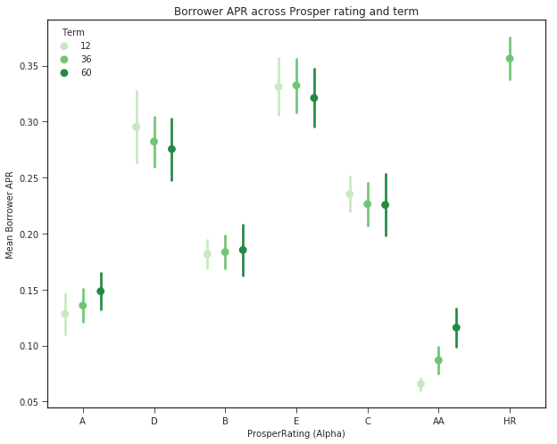

```python
# Exploring the relationship between borrower APR, Term and Prosper Rating
fig = plt.figure(figsize = [10,8])
ax = sb.pointplot(data = loans, x = 'ProsperRating (Alpha)', y = 'BorrowerAPR', hue = 'Term', palette = 'Greens', ci='sd', linestyles = '', dodge = 0.5);
plt.title('Borrower APR across Prosper rating and term')
plt.ylabel('Mean Borrower APR')
ax.set_yticklabels([],minor = True);
```

For AA-B ratings, the APR increases with the increased of loan term. The APR decreases with the increased of loan term for C - HR ratings.

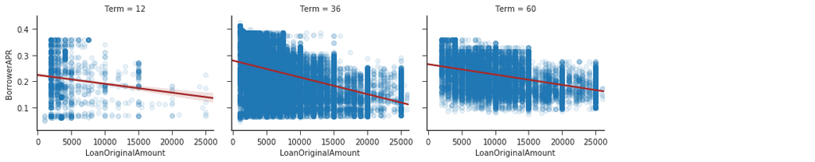

```python
# Term effect on relationship of APR and loan amount
g=sb.FacetGrid(data=loans, aspect=1.2,  col='Term', col_wrap=4)
g.map(sb.regplot, 'LoanOriginalAmount', 'BorrowerAPR', x_jitter=0.04, scatter_kws={'alpha':0.1}, line_kws={'color':'brown'});
g.add_legend();
```

These plots shows that Term doesn't seem to have effect on relationship of APR and loan amount

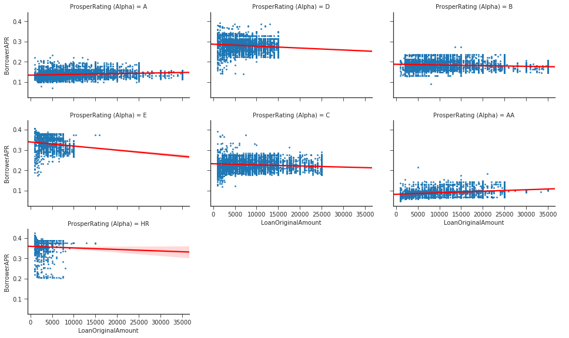

```python
#Effect of ProsperRating (Alpha) on APR and LoanOriginalAmount

g=sb.FacetGrid(data=loans, aspect=1, col='ProsperRating (Alpha)', col_wrap=3)
g.map(sb.regplot, 'LoanOriginalAmount', 'BorrowerAPR', scatter_kws={'s':4}, line_kws={'color':'red'})
g.add_legend();

# set plot dimensions
g.fig.set_size_inches(14, 8)
```

### Talk about some of the relationships you observed in this part of the investigation. Were there features that strengthened each other in terms of looking at your feature(s) of interest?

> The borrower APR decrease with the increase of borrow term for people with HR-C raings. But for people with B-AA ratings, the APR increase with the increase of borrow term.

### Were there any interesting or surprising interactions between features?

> I noticed that the relationship between borrower APR and loan amount turns from negative to slightly positive when the Prosper ratings are increased from HR to A or better. This is may because people with A or AA ratings tend to borrow more money